# Ejercicio 4

Se cargan las liberías necesarias

```r
library(readr)
library(dplyr)
library(traineR)
library(caret)
```

**1. Cargue la tabla de datos titanicV2024.csv, asegúrese de re-codificar las variables cualitativas y de ignorar variables que no se deben usar**

Se carga la base de datos

```r
titanic_datos <- read_csv("titanicV2024.csv")
head(titanic_datos)
```

```
## # A tibble: 6 × 12
##   PassengerId Survived Pclass Name    Sex     Age SibSp Parch Ticket  Fare Cabin
##         <dbl>    <dbl>  <dbl> <chr>   <chr> <dbl> <dbl> <dbl> <chr>  <dbl> <chr>
## 1           1        0      3 Braund… male     22     1     0 A/5 2…  7.25 <NA>
## 2           2        1      1 Cuming… fema…    38     1     0 PC 17… 71.3  C85
## 3           3        1      3 Heikki… fema…    26     0     0 STON/…  7.92 <NA>
## 4           4        1      1 Futrel… fema…    35     1     0 113803 53.1  C123
## 5           5        0      3 Allen,… male     35     0     0 373450  8.05 <NA>
## 6           6        0      3 Moran,… male     NA     0     0 330877  8.46 <NA>
## # ℹ 1 more variable: Embarked <chr>
```

Se identican la cantidad de NA’s presentes en cada variable.

```r
na_variables <- colSums(is.na(titanic_datos))
print(na_variables)
```

```
## PassengerId    Survived      Pclass        Name         Sex         Age
##           0           0           0           0           0         263
##       SibSp       Parch      Ticket        Fare       Cabin    Embarked
##           0           0           0           1        1014           2
```

Se elimina la columna Cabin, pues, contiene muchas observaciones faltantes.

```r
titanic_datos <- titanic_datos[,-11]
```

Se re-codifican las variables cualitativas

```r
titanic_datos <- titanic_datos <- titanic_datos %>%
  mutate( PassengerId = as.factor(PassengerId),
          Survived =  as.factor(Survived),
          Pclass =  as.factor(Pclass),
          Name =  as.factor(Name),
          Sex =  as.factor(Sex),
          Ticket =  as.factor(Ticket),
          Embarked =  as.factor(Embarked))
str(titanic_datos)
```

```
## tibble [1,309 × 11] (S3: tbl_df/tbl/data.frame)
##  $ PassengerId: Factor w/ 1309 levels "1","2","3","4",..: 1 2 3 4 5 6 7 8 9 10 ...
##  $ Survived   : Factor w/ 2 levels "0","1": 1 2 2 2 1 1 1 1 2 2 ...
##  $ Pclass     : Factor w/ 3 levels "1","2","3": 3 1 3 1 3 3 1 3 3 2 ...
##  $ Name       : Factor w/ 1307 levels "Abbing, Mr. Anthony",..: 156 287 531 430 23 826 775 922 613 855 ...
##  $ Sex        : Factor w/ 2 levels "female","male": 2 1 1 1 2 2 2 2 1 1 ...
##  $ Age        : num [1:1309] 22 38 26 35 35 NA 54 2 27 14 ...
##  $ SibSp      : num [1:1309] 1 1 0 1 0 0 0 3 0 1 ...
##  $ Parch      : num [1:1309] 0 0 0 0 0 0 0 1 2 0 ...
##  $ Ticket     : Factor w/ 929 levels "110152","110413",..: 721 817 915 66 650 374 110 542 478 175 ...
##  $ Fare       : num [1:1309] 7.25 71.28 7.92 53.1 8.05 ...
##  $ Embarked   : Factor w/ 3 levels "C","Q","S": 3 1 3 3 3 2 3 3 3 1 ...
```

Además, la variable Age cuenta con datos faltantes. Por tal motivo, se procede a rellenarlos con el promedio de las edades según el sexo.

```r
# Se filtran las edades
mujeres_edades <- na.omit(titanic_datos$Age[titanic_datos$Sex == "female"])
hombres_edades <- na.omit(titanic_datos$Age[titanic_datos$Sex == "male"])

# Se calculan los promedios de las edades
edad_promedio_mujeres <- round(mean(mujeres_edades))
edad_promedio_hombres <- round(mean(hombres_edades))

# Se rellenan los datos faltantes
titanic_datos$Age[titanic_datos$Sex == "female" & is.na(titanic_datos$Age)] <- edad_promedio_mujeres
titanic_datos$Age[titanic_datos$Sex == "male" & is.na(titanic_datos$Age)] <- edad_promedio_hombres
```

También, la variable Embarked presenta dos variables faltantes. Se rellenan con la moda de las cateogrías.

```r
# Se obtiene la moda para la variable Embarked
tabla_frec <- table(titanic_datos$Embarked)  # Se calcula la tabla de frecuencias
moda  <- names(tabla_frec)[which.max(tabla_frec)]  # Encontrar el valor con la frecuencia más alta

# Se rellena el dato faltante
titanic_datos$Embarked[is.na(titanic_datos$Embarked)] <- moda
```

Finalmente, el dato faltante en Fare se rellena con el promedio de las tarifas según el tipo de clase en que viajaba.

```r
# Se identifica la clase en que viajaba
clase <- titanic_datos$Pclass[is.na(titanic_datos$Fare)]

# Se filtran las tarifas según el tipo de clase de viaje
tarifas <- na.omit(titanic_datos$Fare[titanic_datos$Pclass == clase])

# Se obtiene el promedio de las tarifas
tarifa_promedio <- mean(tarifas)

# Se rellena el dato faltante
titanic_datos$Fare[is.na(titanic_datos$Fare)] <- tarifa_promedio
```

**2. Realice un análisis exploratorio (estadísticas básicas) que incluya: el resumen numérico (media, desviación estándar, etc.), los valores atípicos, la correlación entre las variables, el poder predictivo de las variables predictoras. Interprete los resultados**

Se presenta el resumen númerico

```r
summary(titanic_datos)
```

```
##   PassengerId   Survived Pclass                                Name
##  1      :   1   0:815    1:323   Connolly, Miss. Kate            :   2
##  2      :   1   1:494    2:277   Kelly, Mr. James                :   2
##  3      :   1            3:709   Abbing, Mr. Anthony             :   1
##  4      :   1                    Abbott, Master. Eugene Joseph   :   1
##  5      :   1                    Abbott, Mr. Rossmore Edward     :   1
##  6      :   1                    Abbott, Mrs. Stanton (Rosa Hunt):   1
##  (Other):1303                    (Other)                         :1301
##      Sex           Age            SibSp            Parch            Ticket
##  female:466   Min.   : 0.17   Min.   :0.0000   Min.   :0.000   CA. 2343:  11
##  male  :843   1st Qu.:22.00   1st Qu.:0.0000   1st Qu.:0.000   1601    :   8
##               Median :30.00   Median :0.0000   Median :0.000   CA 2144 :   8
##               Mean   :29.99   Mean   :0.4989   Mean   :0.385   3101295 :   7
##               3rd Qu.:35.00   3rd Qu.:1.0000   3rd Qu.:0.000   347077  :   7
##               Max.   :80.00   Max.   :8.0000   Max.   :9.000   347082  :   7
##                                                                (Other) :1261
##       Fare         Embarked
##  Min.   :  0.000   C:270
##  1st Qu.:  7.896   Q:123
##  Median : 14.454   S:916
##  Mean   : 33.280
##  3rd Qu.: 31.275
##  Max.   :512.329
##
```

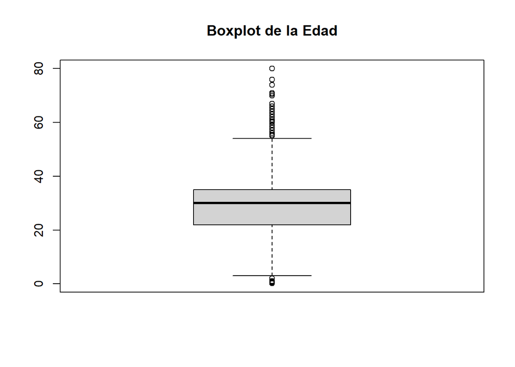

```r
boxplot_edad <- boxplot(titanic_datos$Age, main = "Boxplot de la Edad")
```

**3. ¿Es este problema equilibrado o desequilibrado? Justifique su respuesta**

```r
#prediction.variable.balance(titanic_datos, "Survived")
```